# Predict the Manner of Exercise - Machine Learning Project

Mani Khanuja

27 September 2015

#### Background

Using devices such as Jawbone Up, Nike FuelBand, and Fitbit it is now possible to collect a large amount of data about personal activity relatively inexpensively. These type of devices are part of the quantified self movement - a group of enthusiasts who take measurements about themselves regularly to improve their health, to find patterns in their behavior, or because they are tech geeks. One thing that people regularly do is quantify how much of a particular activity they do, but they rarely quantify how well they do it. In this project, your goal will be to use data from accelerometers on the belt, forearm, arm, and dumbell of 6 participants. These six young health participants were asked to perform one set of 10 repetitions of the Unilateral Dumbbell Biceps Curl in five different fashions:

- Class A: exactly according to the specification
- Class B: throwing the elbows to the front
- Class C: lifting the dumbbell only halfway
- Class D: lowering the dumbbell only halfway
- Class E: throwing the hips to the front

The training data for this project are available here: [https://d396qusza40orc.cloudfront.net/predmachlearn/pml-training.csv]

The test data are available here: [https://d396qusza40orc.cloudfront.net/predmachlearn/pml-testing.csv]

The data for this project come from this source: [http://groupware.les.inf.puc-rio.br/har]. If you use the document you create for this class for any purpose please cite them as they have been very generous in allowing their data to be used for this kind of assignment.

#### Objective

The goal of your project is to predict the manner in which subjects did the exercise. This is the “classe” variable in the training set. Following needs to performed: + Build a machine learning algorithm to predict activity quality from activity monitors. + Describe the expected out of sample error and estimate the error appropriately with cross-validation + Explain the choices made for selecting the machine learning algorithm.

#### Strategy

##### 1. How the model was built

Our outcome variable is classe, a factor variable with 5 levels, as explained above in the background section. Three models will be tested using decision tree(rpart), random forest(rf) and tree boosting(gbm) algorithms. The model with the highest accuracy will be chosen as our final model, this might compromise the performance of the code.

##### 3. Expected out-of-sample error

The expected out-of-sample error will correspond to the quantity: 1-accuracy in the cross-validation data. Expected accuracy is the accuracy expected in the out-of-sample data set (i.e. original testing data set). Thus, the expected value of the out-of-sample error will correspond to the expected number of missclassified observations/total observations in the Test data set, which is the quantity: 1-accuracy found from the cross-validation data set.

#### Code and Results

###### Load the desired packages

```r
library(caret)
library(randomForest)
library(gbm)
library(plyr)
library(dplyr)
library(AppliedPredictiveModeling)
```

###### Setting the overall seed for reproduceability

```r
set.seed(1234)
```

###### Loading and cleaning data

- Load data sets into R
- Make sure missing values are correctly coded.
- Removing the columns which are not required.

```r
# Read Data from csv downloaded
train = read.csv("/Users/manikhanuja/Documents/github/Machine_Learning/Data/pml-training.csv", na.strings=c("NA","#DIV/0!", ""))
test = read.csv("/Users/manikhanuja/Documents/github/Machine_Learning/Data/pml-testing.csv", na.strings=c("NA","#DIV/0!", ""))

# Cleaning data - removing columns which are not required.
training = train[,grepl("belt|arm|dumbbell|classe", colnames(train))]
testing = test[,grepl("belt|arm|dumbbell|classe", colnames(test))]

# Delete columns with all missing values
training<-training[,colSums(is.na(training)) == 0]
testing<-testing[,colSums(is.na(testing)) == 0]
```

###### Subsetting training data for Cross-Validation

In order to perform cross-validation, the training data set is partionned into 2 sets: subTraining (75%) and subTest (25%). This will be performed using random subsampling without replacement.

```r
# Subsampling data from training set for Cross Validation
inTrain <- createDataPartition(y=training$classe, p=0.75, list=FALSE)
subTraining <- training[inTrain, ]
subTesting <- training[-inTrain, ]
dim(subTraining)
```

```
## [1] 14718    53
```

```r
dim(subTesting)
```

```
## [1] 4904   53
```

```r
head(subTraining)
```

```
##   roll_belt pitch_belt yaw_belt total_accel_belt gyros_belt_x gyros_belt_y
## 2      1.41       8.07    -94.4                3         0.02         0.00
## 3      1.42       8.07    -94.4                3         0.00         0.00
## 4      1.48       8.05    -94.4                3         0.02         0.00
## 5      1.48       8.07    -94.4                3         0.02         0.02
## 6      1.45       8.06    -94.4                3         0.02         0.00
## 7      1.42       8.09    -94.4                3         0.02         0.00
##   gyros_belt_z accel_belt_x accel_belt_y accel_belt_z magnet_belt_x
## 2        -0.02          -22            4           22            -7
## 3        -0.02          -20            5           23            -2
## 4        -0.03          -22            3           21            -6
## 5        -0.02          -21            2           24            -6
## 6        -0.02          -21            4           21             0
## 7        -0.02          -22            3           21            -4
##   magnet_belt_y magnet_belt_z roll_arm pitch_arm yaw_arm total_accel_arm
```

[output cut: 69 more lines]

```r
head(subTesting)
```

```
##    roll_belt pitch_belt yaw_belt total_accel_belt gyros_belt_x
## 1       1.41       8.07    -94.4                3         0.00
## 21      1.60       8.10    -94.4                3         0.02
## 22      1.57       8.09    -94.4                3         0.02
## 23      1.56       8.10    -94.3                3         0.02
## 25      1.53       8.11    -94.4                3         0.03
## 26      1.55       8.09    -94.4                3         0.02
##    gyros_belt_y gyros_belt_z accel_belt_x accel_belt_y accel_belt_z
## 1          0.00        -0.02          -21            4           22
## 21         0.00        -0.02          -20            1           20
## 22         0.02        -0.02          -21            3           21
## 23         0.00        -0.02          -21            4           21
## 25         0.00         0.00          -19            4           21
## 26         0.00         0.00          -21            3           22
##    magnet_belt_x magnet_belt_y magnet_belt_z roll_arm pitch_arm yaw_arm
```

[output cut: 69 more lines]

###### Training the Models

Decision tree, random forest and boosting algorithms are known for their ability of detecting the features that are important for classification. Feature selection is inherent, so it is not so necessary at the data preparation phase.Thus, there won’t be any feature selection section for the models used.

First Alogrithm: Decision Tree

```r
modFitDT <- train(classe ~., method = "rpart", data = subTraining)
print(modFitDT$finalModel)
```

```
## n= 14718
##
## node), split, n, loss, yval, (yprob)
##       * denotes terminal node
##
##  1) root 14718 10533 A (0.28 0.19 0.17 0.16 0.18)
##    2) roll_belt< 130.5 13483  9308 A (0.31 0.21 0.19 0.18 0.11)
##      4) pitch_forearm< -34.35 1163     4 A (1 0.0034 0 0 0) *
##      5) pitch_forearm>=-34.35 12320  9304 A (0.24 0.23 0.21 0.2 0.12)
##       10) magnet_dumbbell_y< 439.5 10462  7499 A (0.28 0.18 0.24 0.19 0.11)
##         20) roll_forearm< 123.5 6480  3837 A (0.41 0.18 0.18 0.17 0.06) *
##         21) roll_forearm>=123.5 3982  2663 C (0.08 0.18 0.33 0.22 0.18) *
##       11) magnet_dumbbell_y>=439.5 1858   912 B (0.029 0.51 0.041 0.23 0.19) *
##    3) roll_belt>=130.5 1235    10 E (0.0081 0 0 0 0.99) *
```

```r
confusionMatrix(subTesting$classe, predict(modFitDT, subTesting))
```

```
## Confusion Matrix and Statistics
##
##           Reference
## Prediction    A    B    C    D    E
##          A 1275   28   88    0    4
##          B  390  340  219    0    0
##          C  416   31  408    0    0
##          D  356  141  307    0    0
##          E  134  131  230    0  406
##
## Overall Statistics
##
##                Accuracy : 0.4953
##                  95% CI : (0.4812, 0.5094)
##     No Information Rate : 0.5243
##     P-Value [Acc > NIR] : 1
##
##                   Kappa : 0.3399
##  Mcnemar's Test P-Value : NA
##
## Statistics by Class:
##
##                      Class: A Class: B Class: C Class: D Class: E
## Sensitivity            0.4959  0.50671   0.3259       NA  0.99024
## Specificity            0.9486  0.85613   0.8776   0.8361  0.88985
## Pos Pred Value         0.9140  0.35827   0.4772       NA  0.45061
## Neg Pred Value         0.6307  0.91631   0.7916       NA  0.99900
## Prevalence             0.5243  0.13683   0.2553   0.0000  0.08361
## Detection Rate         0.2600  0.06933   0.0832   0.0000  0.08279
## Detection Prevalence   0.2845  0.19352   0.1743   0.1639  0.18373
## Balanced Accuracy      0.7222  0.68142   0.6017       NA  0.94005
```

Second Algorithm: Boosting for Trees

```r
modFit <- train(classe ~., method = "gbm", data = subTraining, verbose = FALSE)
print(modFit$finalModel)
```

```
## A gradient boosted model with multinomial loss function.
## 150 iterations were performed.
## There were 52 predictors of which 44 had non-zero influence.
```

```r
confusionMatrix(subTesting$classe, predict(modFit, subTesting))
```

```
## Confusion Matrix and Statistics
##
##           Reference
## Prediction    A    B    C    D    E
##          A 1376   11    3    3    2
##          B   30  895   21    2    1
##          C    0   27  818    8    2
##          D    0    3   23  774    4
##          E    1   11   10    4  875
##
## Overall Statistics
##
##                Accuracy : 0.9662
##                  95% CI : (0.9607, 0.971)
##     No Information Rate : 0.2869
##     P-Value [Acc > NIR] : < 2.2e-16
##
##                   Kappa : 0.9572
##  Mcnemar's Test P-Value : 5.63e-05
##
## Statistics by Class:
##
##                      Class: A Class: B Class: C Class: D Class: E
## Sensitivity            0.9780   0.9451   0.9349   0.9785   0.9898
## Specificity            0.9946   0.9864   0.9908   0.9927   0.9935
## Pos Pred Value         0.9864   0.9431   0.9567   0.9627   0.9711
## Neg Pred Value         0.9912   0.9869   0.9859   0.9959   0.9978
## Prevalence             0.2869   0.1931   0.1784   0.1613   0.1803
## Detection Rate         0.2806   0.1825   0.1668   0.1578   0.1784
## Detection Prevalence   0.2845   0.1935   0.1743   0.1639   0.1837
## Balanced Accuracy      0.9863   0.9657   0.9628   0.9856   0.9917
```

Third Algorithm: Random Forests

```r
modFitRF <- train(classe ~., method = "rf", data = subTraining)
print(modFitRF$finalModel)
```

```
##
## Call:
##  randomForest(x = x, y = y, mtry = param$mtry)
##                Type of random forest: classification
##                      Number of trees: 500
## No. of variables tried at each split: 27
##
##         OOB estimate of  error rate: 0.64%
## Confusion matrix:
##      A    B    C    D    E class.error
## A 4178    5    1    0    1 0.001672640
## B   20 2824    4    0    0 0.008426966
## C    0   13 2544   10    0 0.008959875
## D    0    0   22 2387    3 0.010364842
## E    0    3    5    7 2691 0.005543237
```

```r
confusionMatrix(subTesting$classe, predict(modFitRF, subTesting))
```

```
## Confusion Matrix and Statistics
##
##           Reference
## Prediction    A    B    C    D    E
##          A 1395    0    0    0    0
##          B    8  938    3    0    0
##          C    0    8  845    2    0
##          D    0    1    7  796    0
##          E    0    0    1    1  899
##
## Overall Statistics
##
##                Accuracy : 0.9937
##                  95% CI : (0.991, 0.9957)
##     No Information Rate : 0.2861
##     P-Value [Acc > NIR] : < 2.2e-16
##
##                   Kappa : 0.992
##  Mcnemar's Test P-Value : NA
##
## Statistics by Class:
##
##                      Class: A Class: B Class: C Class: D Class: E
## Sensitivity            0.9943   0.9905   0.9871   0.9962   1.0000
## Specificity            1.0000   0.9972   0.9975   0.9981   0.9995
## Pos Pred Value         1.0000   0.9884   0.9883   0.9900   0.9978
## Neg Pred Value         0.9977   0.9977   0.9973   0.9993   1.0000
## Prevalence             0.2861   0.1931   0.1746   0.1629   0.1833
## Detection Rate         0.2845   0.1913   0.1723   0.1623   0.1833
## Detection Prevalence   0.2845   0.1935   0.1743   0.1639   0.1837
## Balanced Accuracy      0.9971   0.9939   0.9923   0.9971   0.9998
```

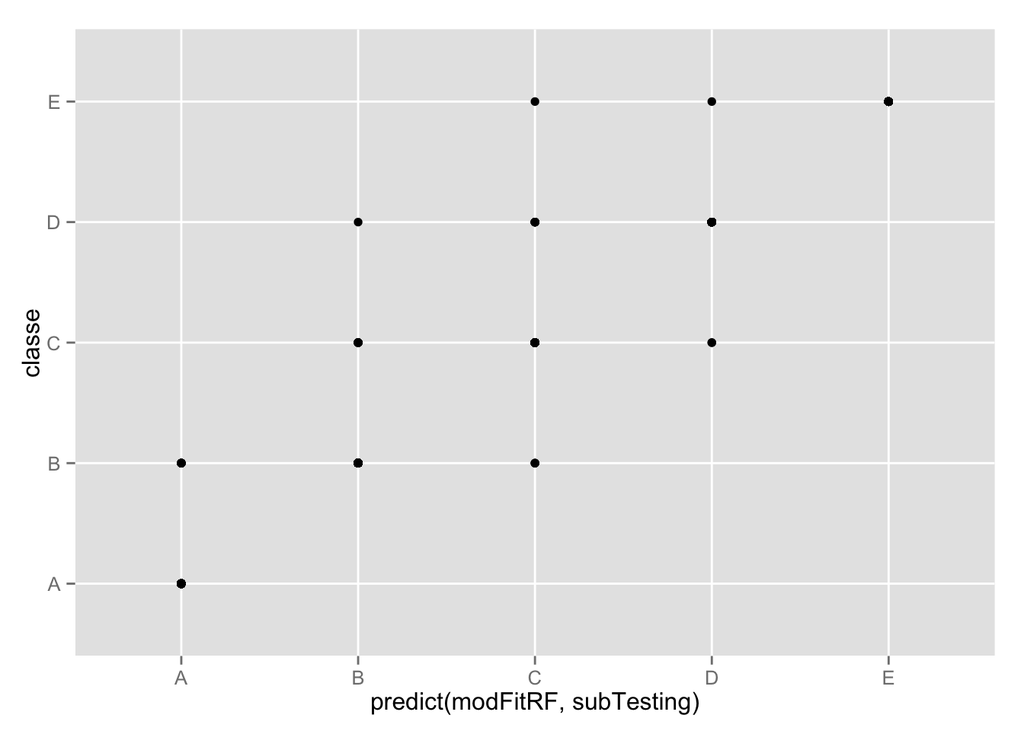

```r
qplot(predict(modFitRF, subTesting), classe, data = subTesting )
```